# Lab 4 - Prominence

Douglas Luke

July 14, 2021

## Introduction

This lab corresponds to Chapter 7 - Actor Prominence.

Typical setup to start.

```r
library(statnet)
library(UserNetR)
library(RColorBrewer)
options(digits=3)
```

## Centrality

We are going to start by examining the centrality of individual tobacco control leaders working in various agencies in DHHS.

First, just do a simple plot to see the basic structure of the network.

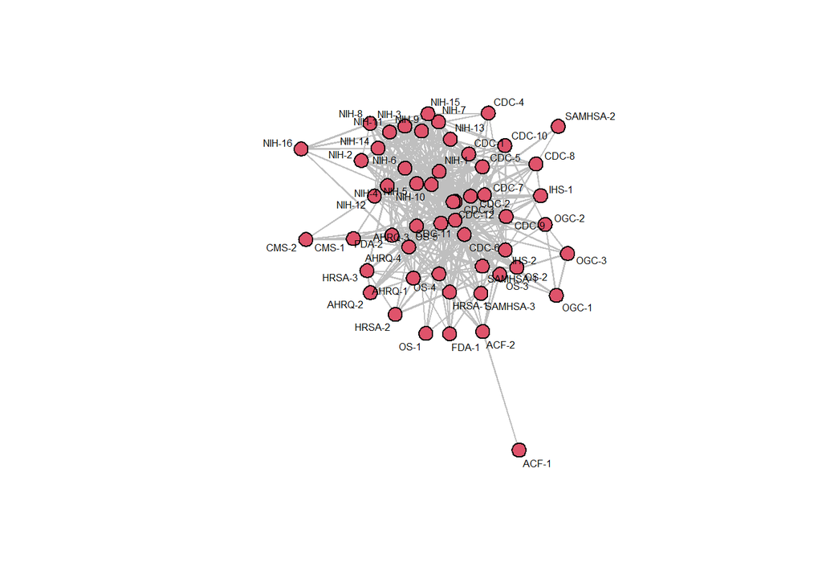

```r
data(DHHS)
plot(DHHS, vertex.cex=2, edge.col="grey75",
     displaylabels=TRUE, label.cex=.5)
```

E: Try playing around with the various plot options to improve (or not) the display of the DHHS network.

It is often useful to examine more than one measure of centrality. This can be particularly useful for larger networks.

Although we have mostly used `statnet` for our network work up to now, here I am going to pop over to `igraph` to calculate PageRank centrality, which is not available in `statnet`.

One thing to watch out for is that R can get confused if you switch back and forth between `statnet` and `igraph` in the same session. (One reason for this is that both packages have functions with the same name.) So, to be safe you want to fully unload (`detach`) one package before loading the other. The following code demonstrates this.

Also, make sure to install the `intergraph` package, which allows us to transform `statnet` network objects to `igraph` and vice versa.

```r
detach("package:statnet", unload=TRUE)
library(igraph)
library(intergraph)
DHHS_i <- asIgraph(DHHS)
```

Once we have the DHHS network transformed into an `igraph` network object, we can perform any network analyses using igraph-specific functionality.

```r
summary(DHHS_i)
```

```
## IGRAPH 40d5d7b U--- 54 447 --
## + attr: title (g/c), agency (v/n), na (v/l), vertex.names (v/c), collab
## | (e/n), na (e/l)
```

```r
PR <- page.rank(DHHS_i)
PR
```

```
## $vector
##  [1] 0.00427 0.01230 0.01626 0.00947 0.02473 0.02290 0.02184 0.02494 0.03953
## [10] 0.00912 0.02287 0.03558 0.02027 0.01340 0.02311 0.01547 0.03531 0.04589
## [19] 0.00963 0.00677 0.00858 0.01920 0.01664 0.00960 0.00975 0.01286 0.01686
## [28] 0.02922 0.01429 0.01888 0.03132 0.02435 0.02532 0.01972 0.01650 0.02152
## [37] 0.02641 0.02130 0.01627 0.01989 0.01925 0.01647 0.00743 0.00822 0.01290
## [46] 0.00819 0.00661 0.01216 0.01580 0.01977 0.04840 0.01605 0.00558 0.01101
##
## $value
## [1] 1
##
## $options
## NULL
```

E: Look up the help entry for `summary.igraph()` to see an explanation of the information contained in the `igraph` network object summary.

E: Look up the help entry for `page.rank()` to see what all the options are.

Note that `PR` is actually a list, and we want to extract the vector in that list which contains the actual PageRank values.

```r
PR <- PR$vector
PR
```

```
##  [1] 0.00427 0.01230 0.01626 0.00947 0.02473 0.02290 0.02184 0.02494 0.03953
## [10] 0.00912 0.02287 0.03558 0.02027 0.01340 0.02311 0.01547 0.03531 0.04589
## [19] 0.00963 0.00677 0.00858 0.01920 0.01664 0.00960 0.00975 0.01286 0.01686
## [28] 0.02922 0.01429 0.01888 0.03132 0.02435 0.02532 0.01972 0.01650 0.02152
## [37] 0.02641 0.02130 0.01627 0.01989 0.01925 0.01647 0.00743 0.00822 0.01290
## [46] 0.00819 0.00661 0.01216 0.01580 0.01977 0.04840 0.01605 0.00558 0.01101
```

Don’t forget to move back to `statnet`.

```r
detach("package:igraph", unload=TRUE)
library(statnet)
```

```r
data(DHHS)
df.prom <- data.frame(
  deg = degree(DHHS),
  cls = closeness(DHHS),
  btw = betweenness(DHHS),
  evc = evcent(DHHS),
  inf = infocent(DHHS),
  flb = flowbet(DHHS),
  pr = PR
  )
```

```r
df.prom
```

```
##    deg   cls     btw     evc   inf  flb      pr
## 1    2 0.349   0.000 0.00183 0.808    0 0.00427
## 2   14 0.530 106.453 0.04005 3.647  306 0.01230
## 3   28 0.570  11.371 0.10178 5.417  440 0.01626
## 4   14 0.525   2.606 0.05328 3.884  214 0.00947
## 5   46 0.631  51.380 0.15525 6.400  940 0.02473
## 6   42 0.616  30.186 0.14870 6.234  742 0.02290
## 7   42 0.616  17.071 0.16734 6.234  550 0.02184
## 8   48 0.639  34.442 0.17967 6.475  762 0.02494
## 9   76 0.768 174.430 0.24176 7.224 1596 0.03953
## 10  14 0.530   1.285 0.06098 3.915  152 0.00912
## 11  44 0.624  21.482 0.17219 6.319  626 0.02287
## 12  66 0.726 167.557 0.19791 7.025 1512 0.03558
## 13  38 0.602  20.021 0.14202 6.048  596 0.02027
## 14  22 0.541   7.695 0.08485 4.853  338 0.01340
```

[output cut: 40 more lines]

```r
cor(df.prom)
```

```
##       deg   cls   btw   evc   inf   flb    pr
## deg 1.000 0.973 0.750 0.972 0.902 0.944 0.996
## cls 0.973 1.000 0.787 0.934 0.890 0.941 0.976
## btw 0.750 0.787 1.000 0.600 0.485 0.884 0.798
## evc 0.972 0.934 0.600 1.000 0.940 0.843 0.949
## inf 0.902 0.890 0.485 0.940 1.000 0.773 0.879
## flb 0.944 0.941 0.884 0.843 0.773 1.000 0.968
## pr  0.996 0.976 0.798 0.949 0.879 0.968 1.000
```

E: Plot some of these centrality values to see how similar they are to one another.

E: Some centrality measures can be produced in a standardize form. Look at the help for `betweenness` to see if you can figure out how this is done. When and why might you use standardized measures of centrality rather than raw measures?

## Centralization

Remember that while centrality is a characteristics of individual network members, centralization is a property of the overall network. That is, a measure of the variability of the individual-level centrality characteristics.

Two network extremes:

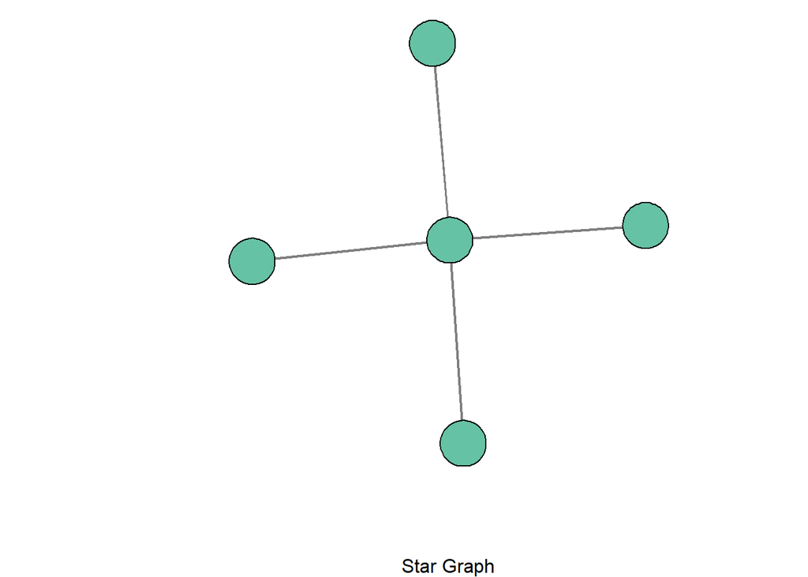

```r
dum1 <- rbind(c(1,2),c(1,3),c(1,4),c(1,5))
star_net <- network(dum1,directed=FALSE)
dum2 <- rbind(c(1,2),c(2,3),c(3,4),c(4,5),c(5,1))
circle_net <- network(dum2,directed=FALSE)
par(mar=c(4,4,.1,.1))
my_pal <- brewer.pal(5,"Set2")
gplot(star_net,usearrows=FALSE,displaylabels=FALSE,
      vertex.cex=2,
      vertex.col=my_pal[1],
      edge.lwd=0,edge.col="grey50",xlab="Star Graph")
```

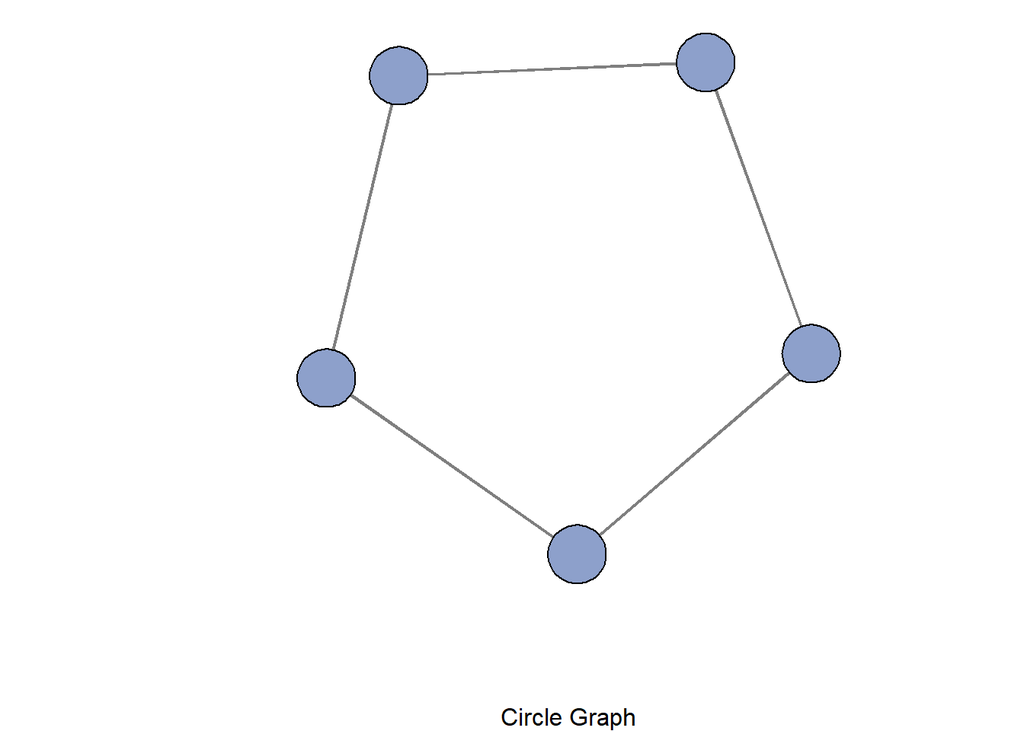

```r
gplot(circle_net,usearrows=FALSE,displaylabels=FALSE,
      vertex.cex=2,
      vertex.col=my_pal[3],
      edge.lwd=0,edge.col="grey50",xlab="Circle Graph")
```

Measures of centralization allow us to compare the two extreme networks.

```r
closeness(circle_net)
```

```
## [1] 0.667 0.667 0.667 0.667 0.667
```

```r
centralization(circle_net,closeness)
```

```
## [1] 0
```

```r
closeness(star_net)
```

```
## [1] 1.000 0.571 0.571 0.571 0.571
```

```r
centralization(star_net,closeness)
```

```
## [1] 0.536
```

## Exploring centrality

How do the Bali network members vary in their prominence?

```r
data(Bali)
str(degree(Bali))
```

```
##  num [1:17] 18 8 18 30 18 20 6 18 18 10 ...
```

```r
summary(degree(Bali))
```

```
##    Min. 1st Qu.  Median    Mean 3rd Qu.    Max.
##     6.0    10.0    18.0    14.8    18.0    30.0
```

Might want to collect different centrality measures together for subsequent display or analysis.

```r
df.prom2 <- data.frame(
  degree = degree(Bali),
  closeness = closeness(Bali),
  betweenness = betweenness(Bali)
  )
row.names(df.prom2) <- Bali %v% "vertex.names"
df.promsort <- df.prom2[order(-df.prom2$degree),]
df.promsort
```

```
##          degree closeness betweenness
## Samudra      30     0.941     122.333
## Idris        20     0.727      12.333
## Muklas       18     0.696       4.667
## Imron        18     0.696       3.333
## Dulmatin     18     0.696       3.333
## Husin        18     0.696       3.333
## Ghoni        18     0.696       3.333
## Patek        18     0.696       3.333
## Sarijo       18     0.696       3.333
## Feri         12     0.485       0.000
## Arnasan      10     0.571       0.000
## Rauf         10     0.571       0.000
## Octavia      10     0.571       0.000
## Hidayat      10     0.571       0.000
## Junaedi      10     0.571       0.000
## Amrozi        8     0.552       0.667
## Mubarok       6     0.533       0.000
```

Q: What pattern do you notice in the numbers for `degree`? Does this make sense to you? Explore the documentation for the `degree()` function to see what the default action is, and a way to change it.

As we discovered last week, visual exploration is often very useful.

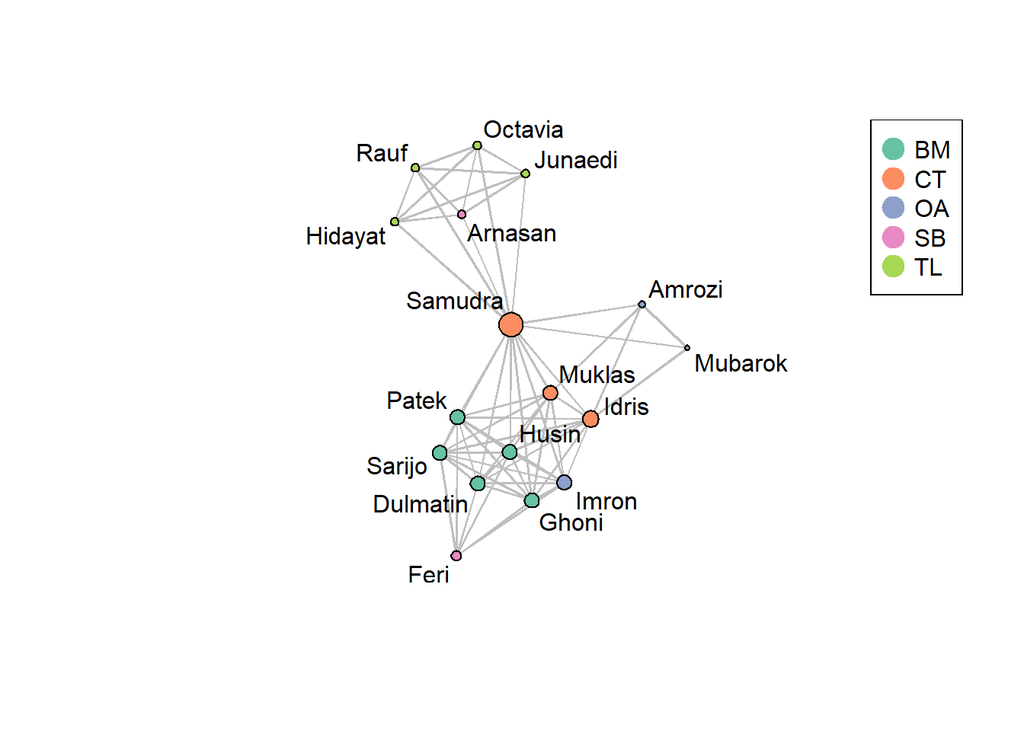

```r
my_pal <- brewer.pal(5,"Set2")
deg <- degree(Bali,rescale=TRUE)
rolecat <- Bali %v% "role"
gplot(Bali,usearrows=FALSE,displaylabels=TRUE,
      vertex.cex=deg*12,
      vertex.col=my_pal[as.factor(rolecat)],
      edge.lwd=0.5,edge.col="grey75")
legend("topright",legend=c("BM","CT","OA","SB","TL"),
       col=my_pal,pch=19,pt.cex=2)
```

## Cutpoints and Bridges

### Cutpoints

Here we will use the Simpsons network to demonstrate cutpoints and bridges, instead of the example network in the book.

[figure not shown]

```r
data(Simpsons)
cpnet <- cutpoints(Simpsons,mode="graph",
                   return.indicator=TRUE)
gplot(Simpsons,gmode="graph",vertex.col=cpnet+2,
      jitter=FALSE,displaylabels=TRUE)
```

Q: What kind of object is returned by the `cutpoints()` function?

This is what happens after dropping Bart from the network (node #3).

```r
net2 <- Simpsons
components(net2)
```

```
## [1] 1
```

```r
delete.vertices(net2,3)
components(net2)
```

```
## [1] 3
```

[figure not shown]

```r
gplot(net2,gmode="graph",vertex.col=2,
      jitter=FALSE,displaylabels=TRUE)
```

E: Using code similar to above, identify the cutpoints for the Bali network.

### Bridges

The is the `bridges()` function from the book.

```r
bridges <- function(dat,mode="graph",
                    connected=c("strong", "weak")) {
  e_cnt <- network.edgecount(dat)
  if (mode == "graph") {
    cmp_cnt <- components(dat)
    b_vec <- rep(FALSE,e_cnt)
    for(i in 1:e_cnt){
      dat2 <- dat
      delete.edges(dat2,i)
      b_vec[i] <- (components(dat2) != cmp_cnt)
      }
  }
  else {
    cmp_cnt <- components(dat,connected=connected)
    b_vec <- rep(FALSE,e_cnt)
    for(i in 1:e_cnt){
      dat2 <- dat
      delete.edges(dat2,i)
      b_vec[i] <- (components(dat2,connected=connected)
        != cmp_cnt)
    }
  }
return(b_vec)
}
```

E: How much of the above function coding can you follow? What happens when the code is run? How can you view the code, once the function has been defined in R?

Now we can use the new function.

```r
brnet <- bridges(Simpsons)
brnet
```

```
##  [1] FALSE FALSE FALSE  TRUE FALSE FALSE FALSE  TRUE FALSE FALSE FALSE FALSE
## [13] FALSE FALSE FALSE FALSE  TRUE FALSE FALSE  TRUE FALSE FALSE FALSE FALSE
```

[figure not shown]

```r
gplot(Simpsons,gmode="graph",vertex.col="red",
      edge.col=brnet+2,
      jitter=FALSE,displaylabels=TRUE)
```

E: Look at the DHHS network and explore the centrality of its members. Identify the most central members based on efficiency of communication. Identify the most central members based on control over communication. Finally, which agencies are most and least central in this network?